# Case Study 3: Combining Heights

Devin W. H.

February 28, 2022

```r
german <- import("https://byuistats.github.io/M335/data/heights/germanconscr.dta")
bavarian <- import("https://byuistats.github.io/M335/data/heights/germanprison.dta")
seswgerman <- import("https://byuistats.github.io/M335/data/heights/Heights_south-east.zip")
bls <- import("https://raw.githubusercontent.com/hadley/r4ds/main/data/heights.csv")
uow <- import("http://www.ssc.wisc.edu/nsfh/wave3/NSFH3%20Apr%202005%20release/main05022005.sav")
```

## Background

One of the important factors in contributing to human growth is diet and physicality. In modern times, the availability of healthy nutrients has increased dramatically due to innovation in farming and industry. This in turn has also brought less stress on the body which has allowed for increased growth, or at least theoretically. Scientific American argues that humans have been getting taller over the years ([link](https://www.scientificamerican.com/article/why-are-we-getting-taller/)). The following case study takes several data sets from various sources to analyze heights of groups throughout history in hopes of analyzing the reality of the situation.

## Data Wrangling

In order to incorporate all the datasets into one, many measures were taken. The goal is to make sure each dataset has a birth year, height in centimeters, height in inches, and a number indicating which study the dataset was originally belonging. Because the first three datasets involved German male soldiers, the last two datasets were narrowed down to white males much as possible in order to maintain consistency.

Check the code comments to see some of the wrangling procedures undertaken in order to get the datasets together.

```r
# Explore datasets
# View(german)
# View(bavarian)
# View(seswgerman)
# View(bls)
# View(uow)

# Dataset 1
ger <- german %>%
  summarise(birth_year = bdec,
            height_cm = height,
            height_in = round(height * 0.393701, 2),
            study = 1)

# Dataset 2
bav <- bavarian %>%
  summarise(birth_year = bdec,
            height_cm = height,
            height_in = round(height * 0.393701, 2),
            study = 2)

# Dataset 3
sger <- seswgerman %>%
  summarise(birth_year = GEBJ,
            height_cm = CMETER,
            height_in = round(CMETER * 0.393701, 2),
            study = 3)

# Dataset 4
# Because the three prior datasets delt with German soldiers from the 20th century, filter dataset to white males to make the data seem more harmonized
bls2 <- bls %>%
  filter(sex == 'male', race == 'white') %>%
  summarise(birth_year = 1950,
            height_cm = round(height * 2.54, 2),
            height_in = height,
            study = 4)

# Dataset 5, simplify columns to what we want first since there is a lot
# No race criteria, simplified it to only males and got rid of abnormalities
uow_wrangled <- uow %>%
  filter(RE35 == 1) %>%
  select(DOBY, RT216F, RT216I) %>%
  mutate(height_in = (RT216F * 12) + RT216I) # Convert feet to inches and add the inches column

uow2 <- uow_wrangled %>%
  summarise(birth_year = DOBY + 1900, # Because DOBY is numeric, we can add 1900 to get full year
            height_cm = round(height_in * 2.54, 2),
            height_in = height_in,
            study = 5)

# Combine wrangled datasets together
dataset <- rbind(ger, bav, sger, bls2, uow2)
dataset$height_in <- round(dataset$height_in, 2)
```

## Data Visualization

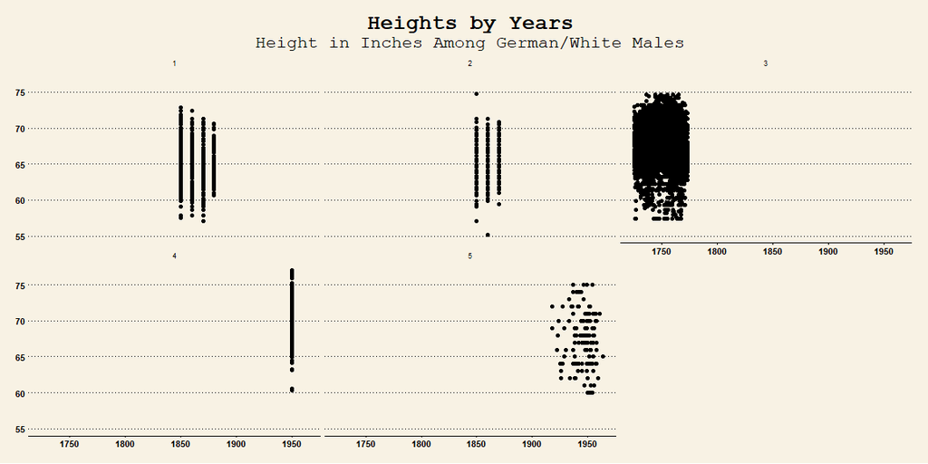

```r
ggplot(dataset) +
  facet_wrap(~ study) +
  aes(x = birth_year, y = height_in) +
  geom_point() +
  scale_x_continuous(breaks = seq(1700, 2000, 50)) +
  labs(x = 'Year', y = 'Height (In)', title = 'Heights by Years', subtitle = 'Height in Inches Among German/White Males') +
  theme_wsj(base_size = 8) +
  theme(plot.title = element_text(hjust = 0.5),
        plot.subtitle = element_text(hjust = 0.5))
```

Taking a quick glance at the above graph, Very little information can be interpreted due to the nature of the studies and how the data was recorded. Faceting by study and analyzing individual heights yields no substantial evidence to indicate overall human height has increased over the years. Perhaps combining the data into one uniform dataframe with the average heights would give a more accurate picture.

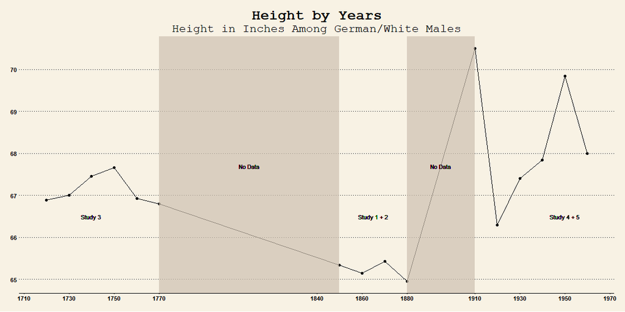

```r
height <- dataset %>%
  mutate(decade = (birth_year %/% 10) * 10) %>%
  group_by(decade) %>%
  mutate(avg_height = mean(height_in))

ggplot(height) +
  aes(x = decade, y = avg_height) +
  geom_point() +
  geom_line() +
  annotate(xmin = 1770, xmax = 1850, ymin = -Inf, ymax = Inf,
           geom = 'rect', fill = "antiquewhite3", color = NA, alpha = .7) +
  annotate(xmin = 1880, xmax = 1910, ymin = -Inf, ymax = Inf,
           geom = 'rect', fill = "antiquewhite3", color = NA, alpha = .7) +
  scale_x_continuous(breaks = c(seq(1710, 1770, by = 20),
                                seq(1840, 1880, by = 20),
                                seq(1910, 1970, by = 20))) +
  geom_text(x = 1810, y = 67.7, label = "No Data",
            color = "black", size = 3) +
  geom_text(x = 1895, y = 67.7, label = "No Data",
            color = "black", size = 3) +
  geom_text(x = 1865, y = 66.5, label = "Study 1 + 2",
            color = "black", size = 3) +
  geom_text(x = 1740, y = 66.5, label = "Study 3",
            color = "black", size = 3) +
  geom_text(x = 1950, y = 66.5, label = "Study 4 + 5",
            color = "black", size = 3) +
  labs(x = 'Decade', y = 'Mean Height in Inches', title = 'Height by Years', subtitle = 'Height in Inches Among German/White Males') +
  theme_wsj(base_size = 8) +
  theme(plot.title = element_text(hjust = 0.5),
        plot.subtitle = element_text(hjust = 0.5))
```

```r
# %/% ex. 1952 %/% 10 = 195, 195 x 10 = 1950
# Treat as numeric or string
```